# Data Science Pipeline Tutorial - Analyzing a COVID-19 Dataset

#### Jonathan Probert, Akash Shetty, Selena Xiao

## Introduction

The COVID-19 pandemic has impacted the world for over a year now, as of the making of this tutorial. Millions of lives have been lost, and even more have contracted this disease. By looking at the data relating to COVID and countries around the world, we can determine how to best react to, prepare for, and eventually eliminate COVID. In this tutorial, we will go through the data science pipeline, including data scraping, cleaning, exploration through visualization, hypothesis testing, and machine learning, in order to gain some insight from this dataset.

## Importing packages

We need to use some Python libraries for storing, visualizing, and analyzing our dataset.

```python
# Storing
import pandas as pd # https://pandas.pydata.org/docs/
import numpy as np # https://numpy.org/doc/

# Visualizing
import matplotlib.pyplot as plt # https://matplotlib.org/stable/contents.html

# Linear regression, machine learning, and Hypothesis Testing
# https://www.statsmodels.org/stable/index.html
import statsmodels.api as sm
from statsmodels.stats.proportion import proportions_ztest

# https://scikit-learn.org/stable/
import sklearn.ensemble
import sklearn.model_selection
import sklearn.metrics
from sklearn.linear_model import LinearRegression
```

## Data Scraping

Data scraping is the process where we import data that isn’t necessarily neatly formatted from a website into a formatted file that we can easily parse through. The dataset that we are using is located at https://covid.ourworldindata.org/data/owid-covid-data.csv and is already in csv format.

It updates daily, so we are using the dataset as it was downloaded on May 03, 2021.

```python
data = pd.read_csv('owid-covid-data.csv')
data.head()
```

|  | iso_code | continent | location | date | total_cases | new_cases | new_cases_smoothed | total_deaths | new_deaths | new_deaths_smoothed | ... | gdp_per_capita | extreme_poverty | cardiovasc_death_rate | diabetes_prevalence | female_smokers | male_smokers | handwashing_facilities | hospital_beds_per_thousand | life_expectancy | human_development_index |
| --- | --- | --- | --- | --- | --- | --- | --- | --- | --- | --- | --- | --- | --- | --- | --- | --- | --- | --- | --- | --- | --- |
| 0 | AFG | Asia | Afghanistan | 2020-02-24 | 1.0 | 1.0 | NaN | NaN | NaN | NaN | ... | 1803.987 | NaN | 597.029 | 9.59 | NaN | NaN | 37.746 | 0.5 | 64.83 | 0.511 |
| 1 | AFG | Asia | Afghanistan | 2020-02-25 | 1.0 | 0.0 | NaN | NaN | NaN | NaN | ... | 1803.987 | NaN | 597.029 | 9.59 | NaN | NaN | 37.746 | 0.5 | 64.83 | 0.511 |
| 2 | AFG | Asia | Afghanistan | 2020-02-26 | 1.0 | 0.0 | NaN | NaN | NaN | NaN | ... | 1803.987 | NaN | 597.029 | 9.59 | NaN | NaN | 37.746 | 0.5 | 64.83 | 0.511 |
| 3 | AFG | Asia | Afghanistan | 2020-02-27 | 1.0 | 0.0 | NaN | NaN | NaN | NaN | ... | 1803.987 | NaN | 597.029 | 9.59 | NaN | NaN | 37.746 | 0.5 | 64.83 | 0.511 |
| 4 | AFG | Asia | Afghanistan | 2020-02-28 | 1.0 | 0.0 | NaN | NaN | NaN | NaN | ... | 1803.987 | NaN | 597.029 | 9.59 | NaN | NaN | 37.746 | 0.5 | 64.83 | 0.511 |

5 rows × 59 columns

## Data Cleaning

Data cleaning is the process where we “clean up” the collected data. Cleaning up can include the following:

1. Accounting for any data scraping errors. If the online dataset doesn’t include column names, then we would have to add those when creating our DataFrame
2. The dataset might be incomplete. Some rows may not have a value in every column. How this missing data is represented depends on the dataset. Looking at the documentation of the online dataset is the best way to determine what constitutes missing. Once we know that, we can then change those values to NaN, which NumPy uses to represent a missing value - https://numpy.org/doc/stable/reference/constants.html#numpy.NAN We perform this change because when the library functions that we use to analyze this data is programmed to skip over the NaN values. In our data, missing values are already written as NaN.

Through data scraping, we have a bunch of data in an organized DataFrame with labelled columns. But this DataFrame contains a TON of information that we may not need. The dataset's README at https://github.com/owid/covid-19-data/tree/master/public/data shows that it contains daily records for cases, deaths, and health statistics for every country in the world. Besides daily information for each country, the data also contains daily information for each continent as well as the entire world.

We remove the rows that contain a non-country value as its location. This is represented in the data as an iso_code starting with OWID.

```python
# deleting references to world data (wrl)
data = data[data.iso_code != 'OWID_WRL']

# # deleting references to Africa (afr)
data = data[data.iso_code != 'OWID_AFR']

# # deleting references to Asia (asi)
data = data[data.iso_code != 'OWID_ASI']

# # deleting references to Europe and EU (EUR and EUN)
data = data[data.iso_code != 'OWID_EUR']
data = data[data.iso_code != 'OWID_EUN']

# # deleting references to North America (nam)
data = data[data.iso_code != 'OWID_NAM']

# # deleting references to Oceania (oce)
data = data[data.iso_code != 'OWID_OCE']

# # deleting references to South America (sam)
data = data[data.iso_code != 'OWID_SAM']
```

Additionally, for initial data exploration, we will only be looking at cases and deaths for the top 50 most populous countries on May 3rd 2021. We drop the unneeded columns.

```python
# Sorting the data by population, we will only look at the top 50 most populous countries
data = data.sort_values(by=['population'] , ascending = False)

# remove data columns that will not be used
data = data.drop(columns=['reproduction_rate', 'icu_patients', 'icu_patients_per_million', 'hosp_patients',
                         'hosp_patients_per_million', 'weekly_icu_admissions', 'weekly_icu_admissions_per_million',
                         'weekly_hosp_admissions', 'weekly_hosp_admissions_per_million', 'new_tests', 'total_tests',
                         'total_tests_per_thousand', 'new_tests_per_thousand', 'new_tests_smoothed',
                         'new_tests_smoothed_per_thousand', 'positive_rate', 'tests_per_case', 'tests_units',
                         'total_vaccinations', 'people_vaccinated', 'people_fully_vaccinated', 'new_vaccinations',
                         'new_vaccinations_smoothed', 'total_vaccinations_per_hundred', 'people_vaccinated_per_hundred',
                         'people_fully_vaccinated_per_hundred', 'new_vaccinations_smoothed_per_million',
                         'stringency_index', 'population_density', 'median_age', 'aged_65_older', 'aged_70_older',
                         'gdp_per_capita', 'extreme_poverty', 'cardiovasc_death_rate', 'diabetes_prevalence',
                         'female_smokers', 'male_smokers', 'hospital_beds_per_thousand',
                         'life_expectancy', 'human_development_index', 'handwashing_facilities'])

data = data.drop(columns=['new_cases_smoothed', 'new_deaths_smoothed', 'total_cases_per_million', 'new_cases_per_million',
                         'new_cases_smoothed_per_million', 'total_deaths_per_million', 'new_deaths_per_million',
                         'new_deaths_smoothed_per_million'])


# getting the data for the latest date available (5/3/2021)
top_50 = data[data.date == '2021-05-03']
top_50 = top_50.head(50)

# create new columns for the averages of new deaths and new cases
# iter through rows of top_50 using the location to get the mean of all new cases/new deaths from that location
avg_new_cases = []
for index, row in top_50.iterrows():
    avg_new_cases.append(data[data.location == row['location']]['new_cases'].mean())

avg_new_deaths = []
for index, row in top_50.iterrows():
    avg_new_deaths.append(data[data.location == row['location']]['new_deaths'].mean())

# add new columns to top_50
top_50['avg_new_cases'] = avg_new_cases
top_50['avg_new_deaths'] = avg_new_deaths

# remove new cases and new deaths columns as they are only for may 3
top_50= top_50.drop(columns=['new_deaths', 'new_cases'])
# remove date because data spans more than just this date
top_50 = top_50.drop(columns=['date'])


top_50
```

|  | iso_code | continent | location | total_cases | total_deaths | population | avg_new_cases | avg_new_deaths |
| --- | --- | --- | --- | --- | --- | --- | --- | --- |
| 16713 | CHN | Asia | China | 102549.0 | 4846.0 | 1.439324e+09 | 218.417559 | 10.340471 |
| 35734 | IND | Asia | India | 20282833.0 | 222408.0 | 1.380004e+09 | 44093.115217 | 530.806683 |
| 81797 | USA | North America | United States | 32472201.0 | 577566.0 | 3.310026e+08 | 69533.618844 | 1343.176744 |
| 36162 | IDN | Asia | Indonesia | 1682004.0 | 45949.0 | 2.735236e+08 | 3929.915888 | 109.663484 |
| 59235 | PAK | Asia | Pakistan | 837523.0 | 18310.0 | 2.208923e+08 | 1929.776498 | 44.441748 |
| 11434 | BRA | South America | Brazil | 14779529.0 | 408622.0 | 2.125594e+08 | 34132.861432 | 989.399516 |
| 56466 | NGA | Africa | Nigeria | 165199.0 | 2063.0 | 2.061396e+08 | 383.292343 | 5.068796 |
| 7106 | BGD | Asia | Bangladesh | 763682.0 | 11644.0 | 1.646894e+08 | 1809.672986 | 28.262136 |
| 64039 | RUS | Europe | Russia | 4776844.0 | 109341.0 | 1.459345e+08 | 10407.067538 | 266.036496 |
| 50338 | MEX | North America | Mexico | 2349900.0 | 217345.0 | 1.289328e+08 | 5452.204176 | 528.819951 |
| 39808 | JPN | Asia | Japan | 609625.0 | 10391.0 | 1.264765e+08 | 1305.402570 | 23.298206 |
| 26005 | ETH | Africa | Ethiopia | 258813.0 | 3757.0 | 1.149636e+08 | 620.654676 | 9.535533 |
| 61858 | PHL | Asia | Philippines | 1062225.0 | 17525.0 | 1.095811e+08 | 2309.184783 | 38.347921 |
| 23503 | EGY | Africa | Egypt | 230713.0 | 13531.0 | 1.023344e+08 | 518.456180 | 32.063981 |
| 84111 | VNM | Asia | Vietnam | 2985.0 | 35.0 | 9.733858e+07 | 6.391863 | 0.126354 |
| 20923 | COD | Africa | Democratic Republic of Congo | 30004.0 | 768.0 | 8.956140e+07 | 71.608592 | 1.877751 |
| 79481 | TUR | Asia | Turkey | 4900121.0 | 41191.0 | 8.433907e+07 | 9753.339713 | 99.736077 |
| 37054 | IRN | Asia | Iran | 2555587.0 | 72875.0 | 8.399295e+07 | 5808.152273 | 165.625000 |
| 30208 | DEU | Europe | Germany | 3438186.0 | 83605.0 | 8.378394e+07 | 7425.887689 | 198.586698 |
| 77373 | THA | Asia | Thailand | 71025.0 | 276.0 | 6.979998e+07 | 152.079229 | 0.643357 |
| 28483 | FRA | Europe | France | 5717160.0 | 105291.0 | 6.814769e+07 | 12268.583691 | 237.141892 |
| 81329 | GBR | Europe | United Kingdom | 4437505.0 | 127797.0 | 6.788600e+07 | 9667.766885 | 301.408019 |
| 38921 | ITA | Europe | Italy | 4050708.0 | 121433.0 | 6.046183e+07 | 8825.071895 | 277.244292 |
| 76887 | TZA | Africa | Tanzania | 509.0 | 21.0 | 5.973421e+07 | 1.229469 | 0.052632 |
| 71275 | ZAF | Africa | South Africa | 1584961.0 | 54452.0 | 5.930869e+07 | 3729.320000 | 135.116625 |
| 53462 | MMR | Asia | Myanmar | 142842.0 | 3209.0 | 5.440979e+07 | 354.446650 | 8.042607 |
| 41168 | KEN | Africa | Kenya | 160559.0 | 2781.0 | 5.377130e+07 | 385.033573 | 6.883663 |
| 72181 | KOR | Asia | South Korea | 124269.0 | 1840.0 | 5.126918e+07 | 266.098501 | 4.191344 |
| 17137 | COL | South America | Colombia | 2905254.0 | 75164.0 | 5.088288e+07 | 6852.014151 | 184.225490 |
| 73033 | ESP | Europe | Spain | 3540430.0 | 78293.0 | 4.675478e+07 | 7730.196507 | 183.355972 |
| 79982 | UGA | Africa | Uganda | 41973.0 | 342.0 | 4.574100e+07 | 102.623472 | 1.204225 |
| 3570 | ARG | South America | Argentina | 3021179.0 | 64792.0 | 4.519578e+07 | 7075.360656 | 153.535545 |
| 1748 | DZA | Africa | Algeria | 122717.0 | 3280.0 | 4.385104e+07 | 282.758065 | 7.846890 |
| 73914 | SDN | Africa | Sudan | 33944.0 | 2349.0 | 4.384927e+07 | 81.596154 | 5.633094 |
| 80409 | UKR | Europe | Ukraine | 2140838.0 | 46607.0 | 4.373376e+07 | 5013.672131 | 111.767386 |
| 37489 | IRQ | Asia | Iraq | 1079998.0 | 15566.0 | 4.022250e+07 | 2482.754023 | 36.539906 |
| 434 | AFG | Asia | Afghanistan | 60300.0 | 2642.0 | 3.892834e+07 | 138.620690 | 6.475490 |
| 62284 | POL | Europe | Poland | 2805756.0 | 68105.0 | 3.784660e+07 | 6586.281690 | 162.930622 |
| 14447 | CAN | North America | Canada | 1251811.0 | 24334.0 | 3.774216e+07 | 2697.868534 | 57.800475 |
| 52651 | MAR | Africa | Morocco | 511912.0 | 9032.0 | 3.691056e+07 | 1196.056075 | 21.504762 |
| 67178 | SAU | Asia | Saudi Arabia | 420301.0 | 6992.0 | 3.481387e+07 | 982.011682 | 17.221675 |
| 82629 | UZB | Asia | Uzbekistan | 92006.0 | 653.0 | 3.346920e+07 | 221.701205 | 1.620347 |
| 61398 | PER | South America | Peru | 1814127.0 | 62375.0 | 3.297185e+07 | 4278.601415 | 152.134146 |
| 2586 | AGO | Africa | Angola | 27133.0 | 603.0 | 3.286627e+07 | 66.178049 | 1.503741 |
| 47553 | MYS | Asia | Malaysia | 417512.0 | 1551.0 | 3.236600e+07 | 897.875269 | 3.755448 |
| 53059 | MOZ | Africa | Mozambique | 70000.0 | 815.0 | 3.125544e+07 | 171.568627 | 2.369186 |
| 30624 | GHA | Africa | Ghana | 92683.0 | 779.0 | 3.107294e+07 | 222.795673 | 1.904645 |
| 84968 | YEM | Asia | Yemen | 6363.0 | 1239.0 | 2.982597e+07 | 16.357326 | 3.357724 |
| 54351 | NPL | Asia | Nepal | 343418.0 | 3362.0 | 2.913681e+07 | 738.533333 | 9.524079 |
| 83644 | VEN | South America | Venezuela | 200931.0 | 2189.0 | 2.843594e+07 | 483.007212 | 5.431762 |

## Data Exploration and Visualization

Data exploration is an important step because it provides an idea on relationships that might exist within the data. This helps guide our data analysis with hypothesis testing and machine learning. One main way of exploration is by actually visualizing this data through plots.

The data contains a column dedicated to total deaths for each country. Let's start by visualizing that.

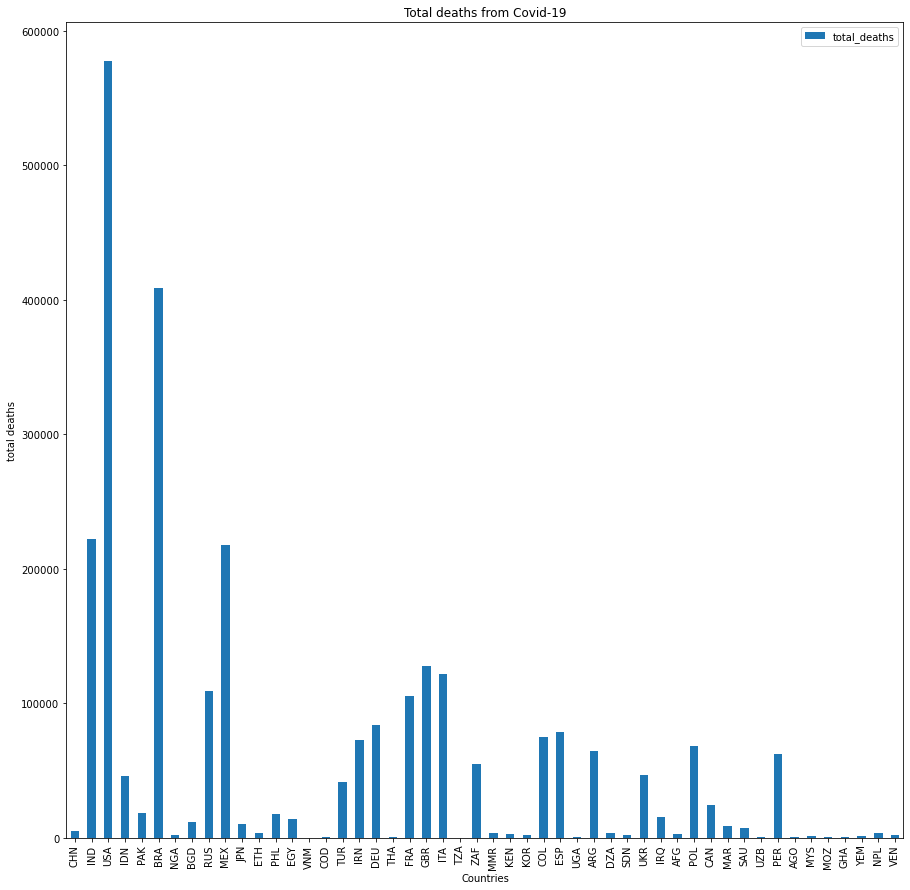

```python
# Plotting the total deaths of the top 50 most populated countries from covid-19

death = top_50.plot(x="iso_code", y="total_deaths", kind="bar", figsize = (15, 15), title = "Total deaths from Covid-19")
death.set_xlabel("Countries")
death.set_ylabel("total deaths")
```

Similarly, we can also visualize the column for total cases.

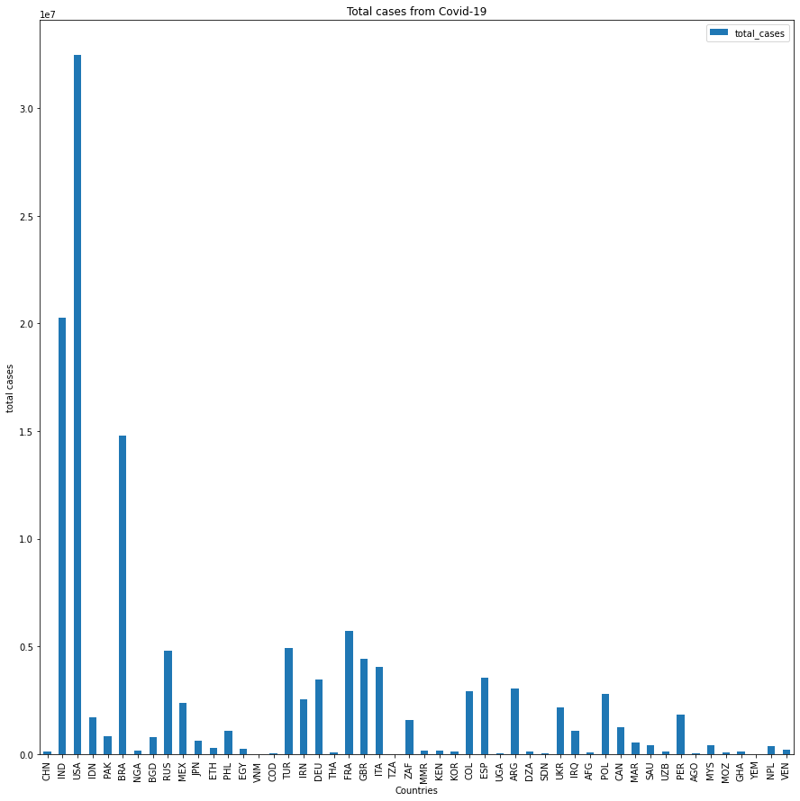

```python
# Plotting the total cases of the top 50 most populated countries from covid-19


cases = top_50.plot(x="iso_code", y="total_cases", kind="bar", figsize = (15, 15), title = "Total cases from Covid-19")
cases.set_xlabel("Countries")
cases.set_ylabel("total cases")
```

While looking at total deaths and cases can give insight into how much a country has been affected, it doesn't take into account the population of that country. For example, Country A may have only 1000 cases, which is miniscule when compared to 1 million cases in Country B. However, Country A may have a population of 10000, while Country B has a population of a billion. In that case, Country A has a larger proportion of its population that has been impacted by COVID.

Even though we are only looking at the top 50 most populous countries, this difference between totals and population is still important. The most populous in our top_50 list, China, has a 1.4 billion population, while the least populous, Venezuela is 28 million. We think this difference in population is large enough, so let's visualize proportion of deaths and cases next.

```python
# adds the proportion of total cases and total deaths compared to the population of the country to top_50
proportion_of_total_cases = []
proportion_of_total_deaths = []
for index, row in top_50.iterrows():
    proportion_of_total_cases.append(row['total_cases'] / row['population'])
    proportion_of_total_deaths.append(row['total_deaths'] / row['population'])

top_50['total_cases / population'] = proportion_of_total_cases
top_50['total_deaths / population'] = proportion_of_total_deaths
top_50
```

|  | iso_code | continent | location | total_cases | total_deaths | population | avg_new_cases | avg_new_deaths | total_cases / population | total_deaths / population |
| --- | --- | --- | --- | --- | --- | --- | --- | --- | --- | --- |
| 16713 | CHN | Asia | China | 102549.0 | 4846.0 | 1.439324e+09 | 218.417559 | 10.340471 | 0.000071 | 3.366859e-06 |
| 35734 | IND | Asia | India | 20282833.0 | 222408.0 | 1.380004e+09 | 44093.115217 | 530.806683 | 0.014698 | 1.611647e-04 |
| 81797 | USA | North America | United States | 32472201.0 | 577566.0 | 3.310026e+08 | 69533.618844 | 1343.176744 | 0.098103 | 1.744898e-03 |
| 36162 | IDN | Asia | Indonesia | 1682004.0 | 45949.0 | 2.735236e+08 | 3929.915888 | 109.663484 | 0.006149 | 1.679891e-04 |
| 59235 | PAK | Asia | Pakistan | 837523.0 | 18310.0 | 2.208923e+08 | 1929.776498 | 44.441748 | 0.003792 | 8.289106e-05 |
| 11434 | BRA | South America | Brazil | 14779529.0 | 408622.0 | 2.125594e+08 | 34132.861432 | 989.399516 | 0.069531 | 1.922390e-03 |
| 56466 | NGA | Africa | Nigeria | 165199.0 | 2063.0 | 2.061396e+08 | 383.292343 | 5.068796 | 0.000801 | 1.000778e-05 |
| 7106 | BGD | Asia | Bangladesh | 763682.0 | 11644.0 | 1.646894e+08 | 1809.672986 | 28.262136 | 0.004637 | 7.070280e-05 |
| 64039 | RUS | Europe | Russia | 4776844.0 | 109341.0 | 1.459345e+08 | 10407.067538 | 266.036496 | 0.032733 | 7.492473e-04 |
| 50338 | MEX | North America | Mexico | 2349900.0 | 217345.0 | 1.289328e+08 | 5452.204176 | 528.819951 | 0.018226 | 1.685724e-03 |
| 39808 | JPN | Asia | Japan | 609625.0 | 10391.0 | 1.264765e+08 | 1305.402570 | 23.298206 | 0.004820 | 8.215758e-05 |
| 26005 | ETH | Africa | Ethiopia | 258813.0 | 3757.0 | 1.149636e+08 | 620.654676 | 9.535533 | 0.002251 | 3.267991e-05 |
| 61858 | PHL | Asia | Philippines | 1062225.0 | 17525.0 | 1.095811e+08 | 2309.184783 | 38.347921 | 0.009694 | 1.599272e-04 |
| 23503 | EGY | Africa | Egypt | 230713.0 | 13531.0 | 1.023344e+08 | 518.456180 | 32.063981 | 0.002255 | 1.322234e-04 |
| 84111 | VNM | Asia | Vietnam | 2985.0 | 35.0 | 9.733858e+07 | 6.391863 | 0.126354 | 0.000031 | 3.595696e-07 |
| 20923 | COD | Africa | Democratic Republic of Congo | 30004.0 | 768.0 | 8.956140e+07 | 71.608592 | 1.877751 | 0.000335 | 8.575122e-06 |
| 79481 | TUR | Asia | Turkey | 4900121.0 | 41191.0 | 8.433907e+07 | 9753.339713 | 99.736077 | 0.058100 | 4.883976e-04 |
| 37054 | IRN | Asia | Iran | 2555587.0 | 72875.0 | 8.399295e+07 | 5808.152273 | 165.625000 | 0.030426 | 8.676323e-04 |
| 30208 | DEU | Europe | Germany | 3438186.0 | 83605.0 | 8.378394e+07 | 7425.887689 | 198.586698 | 0.041036 | 9.978642e-04 |
| 77373 | THA | Asia | Thailand | 71025.0 | 276.0 | 6.979998e+07 | 152.079229 | 0.643357 | 0.001018 | 3.954156e-06 |
| 28483 | FRA | Europe | France | 5717160.0 | 105291.0 | 6.814769e+07 | 12268.583691 | 237.141892 | 0.083894 | 1.545041e-03 |
| 81329 | GBR | Europe | United Kingdom | 4437505.0 | 127797.0 | 6.788600e+07 | 9667.766885 | 301.408019 | 0.065367 | 1.882524e-03 |
| 38921 | ITA | Europe | Italy | 4050708.0 | 121433.0 | 6.046183e+07 | 8825.071895 | 277.244292 | 0.066996 | 2.008424e-03 |
| 76887 | TZA | Africa | Tanzania | 509.0 | 21.0 | 5.973421e+07 | 1.229469 | 0.052632 | 0.000009 | 3.515573e-07 |
| 71275 | ZAF | Africa | South Africa | 1584961.0 | 54452.0 | 5.930869e+07 | 3729.320000 | 135.116625 | 0.026724 | 9.181117e-04 |
| 53462 | MMR | Asia | Myanmar | 142842.0 | 3209.0 | 5.440979e+07 | 354.446650 | 8.042607 | 0.002625 | 5.897835e-05 |
| 41168 | KEN | Africa | Kenya | 160559.0 | 2781.0 | 5.377130e+07 | 385.033573 | 6.883663 | 0.002986 | 5.171904e-05 |
| 72181 | KOR | Asia | South Korea | 124269.0 | 1840.0 | 5.126918e+07 | 266.098501 | 4.191344 | 0.002424 | 3.588901e-05 |
| 17137 | COL | South America | Colombia | 2905254.0 | 75164.0 | 5.088288e+07 | 6852.014151 | 184.225490 | 0.057097 | 1.477196e-03 |
| 73033 | ESP | Europe | Spain | 3540430.0 | 78293.0 | 4.675478e+07 | 7730.196507 | 183.355972 | 0.075723 | 1.674545e-03 |
| 79982 | UGA | Africa | Uganda | 41973.0 | 342.0 | 4.574100e+07 | 102.623472 | 1.204225 | 0.000918 | 7.476881e-06 |
| 3570 | ARG | South America | Argentina | 3021179.0 | 64792.0 | 4.519578e+07 | 7075.360656 | 153.535545 | 0.066846 | 1.433585e-03 |
| 1748 | DZA | Africa | Algeria | 122717.0 | 3280.0 | 4.385104e+07 | 282.758065 | 7.846890 | 0.002798 | 7.479868e-05 |
| 73914 | SDN | Africa | Sudan | 33944.0 | 2349.0 | 4.384927e+07 | 81.596154 | 5.633094 | 0.000774 | 5.356988e-05 |
| 80409 | UKR | Europe | Ukraine | 2140838.0 | 46607.0 | 4.373376e+07 | 5013.672131 | 111.767386 | 0.048952 | 1.065698e-03 |
| 37489 | IRQ | Asia | Iraq | 1079998.0 | 15566.0 | 4.022250e+07 | 2482.754023 | 36.539906 | 0.026851 | 3.869973e-04 |
| 434 | AFG | Asia | Afghanistan | 60300.0 | 2642.0 | 3.892834e+07 | 138.620690 | 6.475490 | 0.001549 | 6.786829e-05 |
| 62284 | POL | Europe | Poland | 2805756.0 | 68105.0 | 3.784660e+07 | 6586.281690 | 162.930622 | 0.074135 | 1.799501e-03 |
| 14447 | CAN | North America | Canada | 1251811.0 | 24334.0 | 3.774216e+07 | 2697.868534 | 57.800475 | 0.033167 | 6.447432e-04 |
| 52651 | MAR | Africa | Morocco | 511912.0 | 9032.0 | 3.691056e+07 | 1196.056075 | 21.504762 | 0.013869 | 2.446996e-04 |
| 67178 | SAU | Asia | Saudi Arabia | 420301.0 | 6992.0 | 3.481387e+07 | 982.011682 | 17.221675 | 0.012073 | 2.008395e-04 |
| 82629 | UZB | Asia | Uzbekistan | 92006.0 | 653.0 | 3.346920e+07 | 221.701205 | 1.620347 | 0.002749 | 1.951048e-05 |
| 61398 | PER | South America | Peru | 1814127.0 | 62375.0 | 3.297185e+07 | 4278.601415 | 152.134146 | 0.055020 | 1.891765e-03 |
| 2586 | AGO | Africa | Angola | 27133.0 | 603.0 | 3.286627e+07 | 66.178049 | 1.503741 | 0.000826 | 1.834708e-05 |
| 47553 | MYS | Asia | Malaysia | 417512.0 | 1551.0 | 3.236600e+07 | 897.875269 | 3.755448 | 0.012900 | 4.792066e-05 |
| 53059 | MOZ | Africa | Mozambique | 70000.0 | 815.0 | 3.125544e+07 | 171.568627 | 2.369186 | 0.002240 | 2.607546e-05 |
| 30624 | GHA | Africa | Ghana | 92683.0 | 779.0 | 3.107294e+07 | 222.795673 | 1.904645 | 0.002983 | 2.507004e-05 |
| 84968 | YEM | Asia | Yemen | 6363.0 | 1239.0 | 2.982597e+07 | 16.357326 | 3.357724 | 0.000213 | 4.154098e-05 |
| 54351 | NPL | Asia | Nepal | 343418.0 | 3362.0 | 2.913681e+07 | 738.533333 | 9.524079 | 0.011786 | 1.153867e-04 |
| 83644 | VEN | South America | Venezuela | 200931.0 | 2189.0 | 2.843594e+07 | 483.007212 | 5.431762 | 0.007066 | 7.698004e-05 |

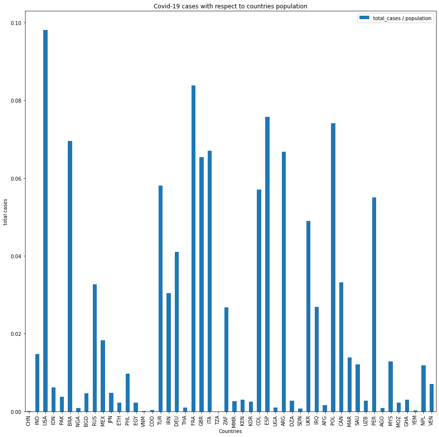

```python
# Plotting the cases / population of the top 50 most populated countries from covid-19

cases_ratio = top_50.plot(x="iso_code", y="total_cases / population", kind="bar", figsize = (15, 15), title = "Covid-19 cases with respect to countries population")
cases_ratio.set_xlabel("Countries")
cases_ratio.set_ylabel("total cases")
```

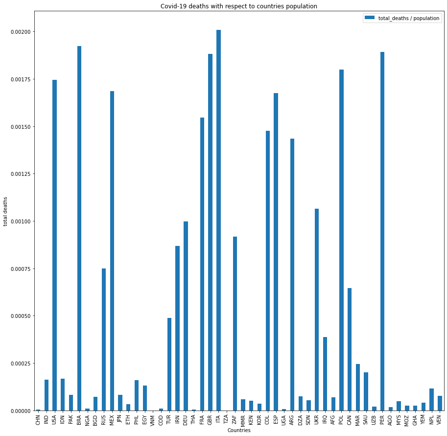

```python
# Plotting the deaths / population of the top 50 most populated countries from covid-19

death_ratio = top_50.plot(x="iso_code", y="total_deaths / population", kind="bar", figsize = (15, 15), title = "Covid-19 deaths with respect to countries population")
death_ratio.set_xlabel("Countries")
death_ratio.set_ylabel("total deaths")
```

The first 2 plots (totals) suggested that USA has been impacted far more than almost every other country in the list, because it had more deaths and cases. The 3rd and 4th plots (proportions) suggests that the countries had more similar impacts than the totals plots suggested - there is less drastic visual difference between the bars.

Our previous visualizations for total deaths/cases and proportion of deaths/cases provide insight on how the top 50 most populous countries have been impacted **so far** by the pandemic.

In the data cleaning step, we added a column for the average amount of new deaths and new cases for each country. This average gives a clue on how much cases and deaths will increase in the future - how each country **will** be impacted.

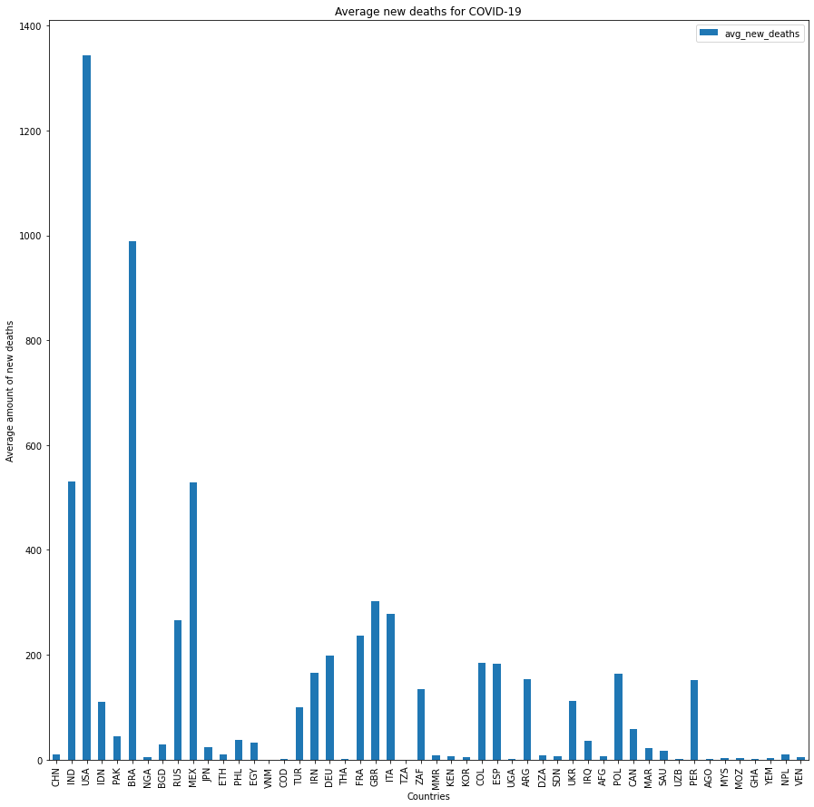

```python
avg_new_deaths_plot = top_50.plot(x="iso_code", y="avg_new_deaths", kind="bar", figsize = (15, 15), title = "Average new deaths for COVID-19")
avg_new_deaths_plot.set_xlabel("Countries")
avg_new_deaths_plot.set_ylabel("Average amount of new deaths")
```

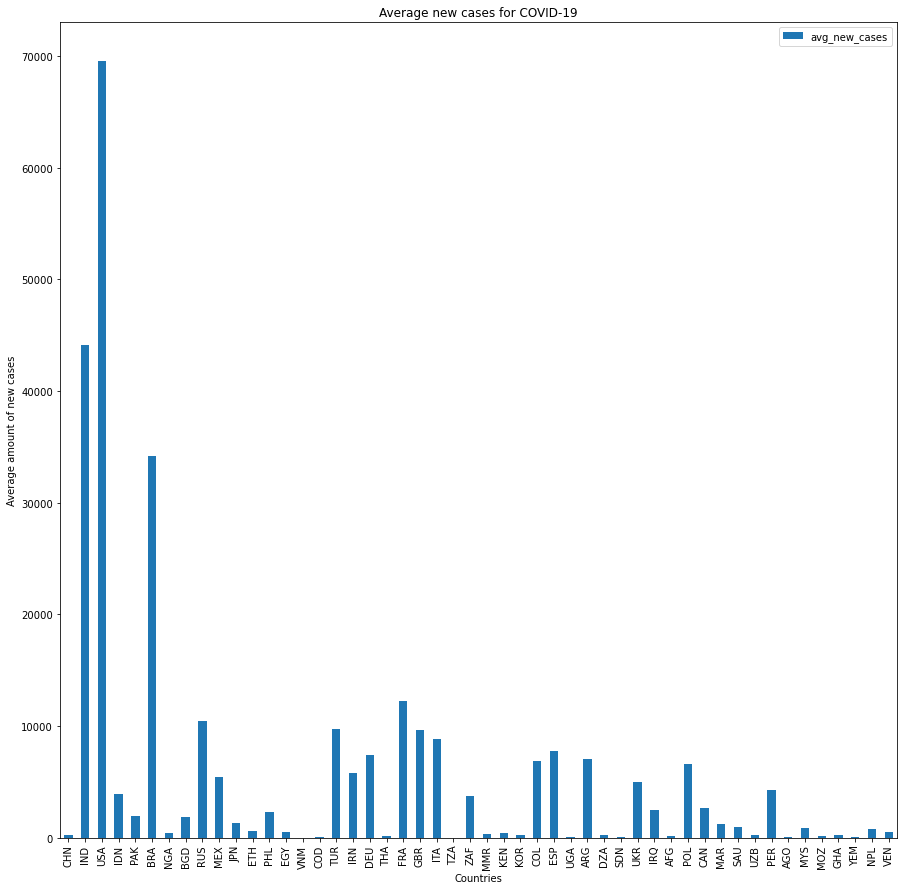

```python
avg_new_cases_plot = top_50.plot(x="iso_code", y="avg_new_cases", kind="bar", figsize = (15, 15), title = "Average new cases for COVID-19")
avg_new_cases_plot.set_xlabel("Countries")
avg_new_cases_plot.set_ylabel("Average amount of new cases")
```

The averages plots look similar to the totals plots in that a few countries look like they are more severely impacted than other countries.

## Hypothesis Testing

Now we move onto Hypothesis Testing. Hypothesis Testing is typically used to test your data for specific results. In most cases of Hypothesis Testing, you have two hypotheses that you want to use to compare data: The null hypothesis and the alternative hypothesis, which contradict each other. You want to set up your data in a way that you will reject your null hypothesis. This basically means that the null hypothesis is your default, your data is assumed to be true to the null hypothesis. If you reject your null hypothesis it means you have enough data to conclude that the null hypothesis is not true and the data favors the alternative hypothesis. To accurately check if your data rejects the null hypothesis we need to use a significance level. This is a certain value that is used to check whether or not to reject, typically this number is set to 0.05, but 0.01 and 0.10 are also used. Depending on the type of Hypothesis Test that you are using there are certain ways find a value called the p-value. This is the value that you calculate and compare to the significance level. If the p-value is less than the significance level than we reject the null hypothesis, if it is greater(or equal to) we fail to reject it. Here is more on Hypothesis Testing: https://en.wikipedia.org/wiki/Statistical_hypothesis_testing

Now lets look at our data.

Our graphs from the total cases and deaths have a similar outcome as those of the average new cases and deaths. Since this is the case it will be the case that the proportion of total deaths and total cases to population will more accurately represent how well certain countries did compared to others. Of the countries with the highest proportions, we will conduct hypothesis tests with the following hypothesis test formulas:

$$significance\,level\, \alpha = 0.05$$\begin{align} H_0 & : p_1 = p_2 \qquad \\ H_a & : p_1 \ne p_2 \qquad \end{align}

Where p1 and p2 are the proportions of cases or deaths to population for countries 1 and 2.

If we reject the null hypothesis it means that country 1 has a different proportion of cases/deaths to population, and if this happens it means that the country with the higher proportion has been hit harder by COVID-19.

The formula below is what the following code is using to find the text statistic Z. The Z value is then used to find the pvalue using a standard normal z-table:(provided in the link) https://www.math.arizona.edu/~rsims/ma464/standardnormaltable.pdf

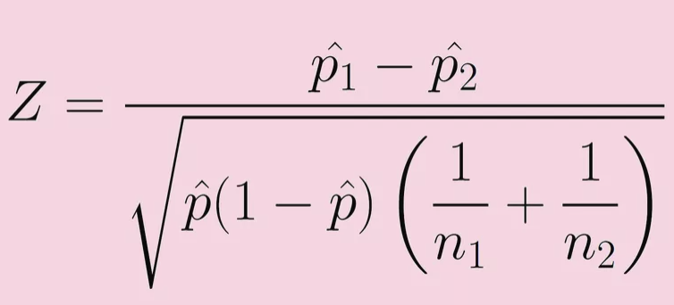

```python
# sort by cases proportion
sort_by_cases_prop = top_50.sort_values(by=['total_cases / population'], ascending=False)

new = {}
hypothesis_of_cases = pd.DataFrame(new, columns = ['country1', 'proportion1', 'country2', 'proportion2', 'pvalue', 'result'])
# loops through the list of countries sorted highest proportion to lowest comparing the current index to the one below it.
for i in range(49):
    sig = 0.05 # for 2 sided

    #gets the total cases and populations for the current country and the country with the next highest proportion to compare
    sample_succ_a, sample_size_a = (sort_by_cases_prop.iloc[i]['total_cases'], sort_by_cases_prop.iloc[i]['population'])
    sample_succ_b, sample_size_b = (sort_by_cases_prop.iloc[i+1]['total_cases'], sort_by_cases_prop.iloc[i+1]['population'])
    #creates an array of the total_cases and populations of both countries
    successes = np.array([sample_succ_a, sample_succ_b])
    samples = np.array([sample_size_a, sample_size_b])

    #uses the stated formula for Z to find the stat value from the previous data and uses a normal z table to find the pvalue
    stat, pvalue = proportions_ztest(count=successes, nobs=samples,  alternative='two-sided')

    #compares the obtained pvalue and compares it to our significance level.
    if pvalue >= sig: reject_check = 'fail to reject null hypothesis'
    else: reject_check = 'reject null hypothesis'

    #create new row to add to dataframe
    result_to_add = {'country1':sort_by_cases_prop.iloc[i]['location'], 'proportion1':sort_by_cases_prop.iloc[i]['total_cases / population'],
                    'country2':sort_by_cases_prop.iloc[i+1]['location'], 'proportion2':sort_by_cases_prop.iloc[i+1]['total_cases / population'],
                    'pvalue':pvalue,'result':reject_check}

    #append to dataframe
    hypothesis_of_cases = hypothesis_of_cases.append(result_to_add, ignore_index=True)

hypothesis_of_cases
```

|  | country1 | proportion1 | country2 | proportion2 | pvalue | result |
| --- | --- | --- | --- | --- | --- | --- |
| 0 | United States | 0.098103 | France | 0.083894 | 0.000000e+00 | reject null hypothesis |
| 1 | France | 0.083894 | Spain | 0.075723 | 0.000000e+00 | reject null hypothesis |
| 2 | Spain | 0.075723 | Poland | 0.074135 | 2.016243e-167 | reject null hypothesis |
| 3 | Poland | 0.074135 | Brazil | 0.069531 | 0.000000e+00 | reject null hypothesis |
| 4 | Brazil | 0.069531 | Italy | 0.066996 | 0.000000e+00 | reject null hypothesis |
| 5 | Italy | 0.066996 | Argentina | 0.066846 | 2.326490e-03 | reject null hypothesis |
| 6 | Argentina | 0.066846 | United Kingdom | 0.065367 | 1.213026e-211 | reject null hypothesis |
| 7 | United Kingdom | 0.065367 | Turkey | 0.058100 | 0.000000e+00 | reject null hypothesis |
| 8 | Turkey | 0.058100 | Colombia | 0.057097 | 9.113333e-130 | reject null hypothesis |
| 9 | Colombia | 0.057097 | Peru | 0.055020 | 0.000000e+00 | reject null hypothesis |
| 10 | Peru | 0.055020 | Ukraine | 0.048952 | 0.000000e+00 | reject null hypothesis |
| 11 | Ukraine | 0.048952 | Germany | 0.041036 | 0.000000e+00 | reject null hypothesis |
| 12 | Germany | 0.041036 | Canada | 0.033167 | 0.000000e+00 | reject null hypothesis |
| 13 | Canada | 0.033167 | Russia | 0.032733 | 1.054706e-40 | reject null hypothesis |
| 14 | Russia | 0.032733 | Iran | 0.030426 | 0.000000e+00 | reject null hypothesis |
| 15 | Iran | 0.030426 | Iraq | 0.026851 | 0.000000e+00 | reject null hypothesis |
| 16 | Iraq | 0.026851 | South Africa | 0.026724 | 1.222757e-04 | reject null hypothesis |
| 17 | South Africa | 0.026724 | Mexico | 0.018226 | 0.000000e+00 | reject null hypothesis |
| 18 | Mexico | 0.018226 | India | 0.014698 | 0.000000e+00 | reject null hypothesis |
| 19 | India | 0.014698 | Morocco | 0.013869 | 0.000000e+00 | reject null hypothesis |
| 20 | Morocco | 0.013869 | Malaysia | 0.012900 | 3.686844e-268 | reject null hypothesis |
| 21 | Malaysia | 0.012900 | Saudi Arabia | 0.012073 | 1.595765e-204 | reject null hypothesis |
| 22 | Saudi Arabia | 0.012073 | Nepal | 0.011786 | 8.565071e-26 | reject null hypothesis |
| 23 | Nepal | 0.011786 | Philippines | 0.009694 | 0.000000e+00 | reject null hypothesis |
| 24 | Philippines | 0.009694 | Venezuela | 0.007066 | 0.000000e+00 | reject null hypothesis |
| 25 | Venezuela | 0.007066 | Indonesia | 0.006149 | 0.000000e+00 | reject null hypothesis |
| 26 | Indonesia | 0.006149 | Japan | 0.004820 | 0.000000e+00 | reject null hypothesis |
| 27 | Japan | 0.004820 | Bangladesh | 0.004637 | 5.939669e-113 | reject null hypothesis |
| 28 | Bangladesh | 0.004637 | Pakistan | 0.003792 | 0.000000e+00 | reject null hypothesis |
| 29 | Pakistan | 0.003792 | Kenya | 0.002986 | 0.000000e+00 | reject null hypothesis |
| 30 | Kenya | 0.002986 | Ghana | 0.002983 | 7.942868e-01 | fail to reject null hypothesis |
| 31 | Ghana | 0.002983 | Algeria | 0.002798 | 9.166065e-49 | reject null hypothesis |
| 32 | Algeria | 0.002798 | Uzbekistan | 0.002749 | 4.133727e-05 | reject null hypothesis |
| 33 | Uzbekistan | 0.002749 | Myanmar | 0.002625 | 1.088500e-27 | reject null hypothesis |
| 34 | Myanmar | 0.002625 | South Korea | 0.002424 | 2.124719e-94 | reject null hypothesis |
| 35 | South Korea | 0.002424 | Egypt | 0.002255 | 2.119666e-94 | reject null hypothesis |
| 36 | Egypt | 0.002255 | Ethiopia | 0.002251 | 6.150558e-01 | fail to reject null hypothesis |
| 37 | Ethiopia | 0.002251 | Mozambique | 0.002240 | 2.227498e-01 | fail to reject null hypothesis |
| 38 | Mozambique | 0.002240 | Afghanistan | 0.001549 | 0.000000e+00 | reject null hypothesis |
| 39 | Afghanistan | 0.001549 | Thailand | 0.001018 | 0.000000e+00 | reject null hypothesis |
| 40 | Thailand | 0.001018 | Uganda | 0.000918 | 2.238288e-63 | reject null hypothesis |
| 41 | Uganda | 0.000918 | Angola | 0.000826 | 4.919092e-42 | reject null hypothesis |
| 42 | Angola | 0.000826 | Nigeria | 0.000801 | 5.705527e-06 | reject null hypothesis |
| 43 | Nigeria | 0.000801 | Sudan | 0.000774 | 6.031548e-09 | reject null hypothesis |
| 44 | Sudan | 0.000774 | Democratic Republic of Congo | 0.000335 | 0.000000e+00 | reject null hypothesis |
| 45 | Democratic Republic of Congo | 0.000335 | Yemen | 0.000213 | 1.521853e-238 | reject null hypothesis |
| 46 | Yemen | 0.000213 | China | 0.000071 | 0.000000e+00 | reject null hypothesis |
| 47 | China | 0.000071 | Vietnam | 0.000031 | 0.000000e+00 | reject null hypothesis |
| 48 | Vietnam | 0.000031 | Tanzania | 0.000009 | 1.695473e-179 | reject null hypothesis |

```python
# sort by deaths proportion
sort_by_deaths_prop = top_50.sort_values(by=['total_deaths / population'], ascending=False)

new = {}
hypothesis_of_deaths = pd.DataFrame(new, columns = ['country1', 'proportion1', 'country2', 'proportion2', 'pvalue', 'result'])
# loops through the list of countries sorted highest proportion to lowest comparing the current index to the one below it.
for i in range(49):
    sig = 0.05 # for 2 sided

    #gets the total deaths and populations for the current country and the country with the next highest proportion to compare
    sample_succ_a, sample_size_a = (sort_by_cases_prop.iloc[i]['total_deaths'], sort_by_cases_prop.iloc[i]['population'])
    sample_succ_b, sample_size_b = (sort_by_cases_prop.iloc[i+1]['total_deaths'], sort_by_cases_prop.iloc[i+1]['population'])
    #creates an array of the total_deaths and populations of both countries
    successes = np.array([sample_succ_a, sample_succ_b])
    samples = np.array([sample_size_a, sample_size_b])

    #uses the stated formula for Z to find the stat value from the previous data and uses a normal z table to find the pvalue
    stat, pvalue = proportions_ztest(count=successes, nobs=samples,  alternative='two-sided')

    #compares the obtained pvalue and compares it to our significance level.
    if pvalue >= sig: reject_check = 'fail to reject null hypothesis'
    else: reject_check = 'reject null hypothesis'

    #create new row to add to dataframe
    result_to_add = {'country1':sort_by_cases_prop.iloc[i]['location'], 'proportion1':sort_by_cases_prop.iloc[i]['total_cases / population'],
                    'country2':sort_by_cases_prop.iloc[i+1]['location'], 'proportion2':sort_by_cases_prop.iloc[i+1]['total_cases / population'],
                    'pvalue':pvalue,'result':reject_check}

    #append to dataframe
    hypothesis_of_deaths = hypothesis_of_deaths.append(result_to_add, ignore_index=True)


hypothesis_of_deaths
```

|  | country1 | proportion1 | country2 | proportion2 | pvalue | result |
| --- | --- | --- | --- | --- | --- | --- |
| 0 | United States | 0.098103 | France | 0.083894 | 2.167871e-289 | reject null hypothesis |
| 1 | France | 0.083894 | Spain | 0.075723 | 2.293252e-65 | reject null hypothesis |
| 2 | Spain | 0.075723 | Poland | 0.074135 | 5.119302e-43 | reject null hypothesis |
| 3 | Poland | 0.074135 | Brazil | 0.069531 | 1.795302e-57 | reject null hypothesis |
| 4 | Brazil | 0.069531 | Italy | 0.066996 | 5.313116e-41 | reject null hypothesis |
| 5 | Italy | 0.066996 | Argentina | 0.066846 | 0.000000e+00 | reject null hypothesis |
| 6 | Argentina | 0.066846 | United Kingdom | 0.065367 | 0.000000e+00 | reject null hypothesis |
| 7 | United Kingdom | 0.065367 | Turkey | 0.058100 | 0.000000e+00 | reject null hypothesis |
| 8 | Turkey | 0.058100 | Colombia | 0.057097 | 0.000000e+00 | reject null hypothesis |
| 9 | Colombia | 0.057097 | Peru | 0.055020 | 0.000000e+00 | reject null hypothesis |
| 10 | Peru | 0.055020 | Ukraine | 0.048952 | 0.000000e+00 | reject null hypothesis |
| 11 | Ukraine | 0.048952 | Germany | 0.041036 | 4.965024e-30 | reject null hypothesis |
| 12 | Germany | 0.041036 | Canada | 0.033167 | 0.000000e+00 | reject null hypothesis |
| 13 | Canada | 0.033167 | Russia | 0.032733 | 6.157835e-100 | reject null hypothesis |
| 14 | Russia | 0.032733 | Iran | 0.030426 | 3.395778e-207 | reject null hypothesis |
| 15 | Iran | 0.030426 | Iraq | 0.026851 | 0.000000e+00 | reject null hypothesis |
| 16 | Iraq | 0.026851 | South Africa | 0.026724 | 0.000000e+00 | reject null hypothesis |
| 17 | South Africa | 0.026724 | Mexico | 0.018226 | 0.000000e+00 | reject null hypothesis |
| 18 | Mexico | 0.018226 | India | 0.014698 | 0.000000e+00 | reject null hypothesis |
| 19 | India | 0.014698 | Morocco | 0.013869 | 0.000000e+00 | reject null hypothesis |
| 20 | Morocco | 0.013869 | Malaysia | 0.012900 | 0.000000e+00 | reject null hypothesis |
| 21 | Malaysia | 0.012900 | Saudi Arabia | 0.012073 | 0.000000e+00 | reject null hypothesis |
| 22 | Saudi Arabia | 0.012073 | Nepal | 0.011786 | 1.274552e-157 | reject null hypothesis |
| 23 | Nepal | 0.011786 | Philippines | 0.009694 | 6.280546e-68 | reject null hypothesis |
| 24 | Philippines | 0.009694 | Venezuela | 0.007066 | 1.586717e-238 | reject null hypothesis |
| 25 | Venezuela | 0.007066 | Indonesia | 0.006149 | 4.898484e-293 | reject null hypothesis |
| 26 | Indonesia | 0.006149 | Japan | 0.004820 | 0.000000e+00 | reject null hypothesis |
| 27 | Japan | 0.004820 | Bangladesh | 0.004637 | 8.247610e-29 | reject null hypothesis |
| 28 | Bangladesh | 0.004637 | Pakistan | 0.003792 | 3.904043e-41 | reject null hypothesis |
| 29 | Pakistan | 0.003792 | Kenya | 0.002986 | 4.955222e-121 | reject null hypothesis |
| 30 | Kenya | 0.002986 | Ghana | 0.002983 | 1.817314e-74 | reject null hypothesis |
| 31 | Ghana | 0.002983 | Algeria | 0.002798 | 1.470131e-182 | reject null hypothesis |
| 32 | Algeria | 0.002798 | Uzbekistan | 0.002749 | 4.607729e-250 | reject null hypothesis |
| 33 | Uzbekistan | 0.002749 | Myanmar | 0.002625 | 9.215856e-162 | reject null hypothesis |
| 34 | Myanmar | 0.002625 | South Korea | 0.002424 | 5.049404e-66 | reject null hypothesis |
| 35 | South Korea | 0.002424 | Egypt | 0.002255 | 0.000000e+00 | reject null hypothesis |
| 36 | Egypt | 0.002255 | Ethiopia | 0.002251 | 0.000000e+00 | reject null hypothesis |
| 37 | Ethiopia | 0.002251 | Mozambique | 0.002240 | 4.767667e-09 | reject null hypothesis |
| 38 | Mozambique | 0.002240 | Afghanistan | 0.001549 | 1.023181e-135 | reject null hypothesis |
| 39 | Afghanistan | 0.001549 | Thailand | 0.001018 | 0.000000e+00 | reject null hypothesis |
| 40 | Thailand | 0.001018 | Uganda | 0.000918 | 1.176062e-15 | reject null hypothesis |
| 41 | Uganda | 0.000918 | Angola | 0.000826 | 8.789299e-43 | reject null hypothesis |
| 42 | Angola | 0.000826 | Nigeria | 0.000801 | 2.505986e-40 | reject null hypothesis |
| 43 | Nigeria | 0.000801 | Sudan | 0.000774 | 0.000000e+00 | reject null hypothesis |
| 44 | Sudan | 0.000774 | Democratic Republic of Congo | 0.000335 | 0.000000e+00 | reject null hypothesis |
| 45 | Democratic Republic of Congo | 0.000335 | Yemen | 0.000213 | 0.000000e+00 | reject null hypothesis |
| 46 | Yemen | 0.000213 | China | 0.000071 | 0.000000e+00 | reject null hypothesis |
| 47 | China | 0.000071 | Vietnam | 0.000031 | 2.109011e-58 | reject null hypothesis |
| 48 | Vietnam | 0.000031 | Tanzania | 0.000009 | 9.349306e-01 | fail to reject null hypothesis |

Most of our data has the same result: reject the null hypothesis. This means that, for the majority of the coutries, the country with the higher proportion of cases to population or deaths to poulation was affected harder by COVID-19.

There were a few cases where we failed to reject the null hypothesis. In the cases / population we had that:

Egypt = Ethiopia

Ethiopia = Mozambique

Kenya = Ghana

and in deaths / population we had: Vietnam = Tanzania.

This means that for those countries the proportion of cases to population or deaths to population was not significantly different and they were affected roughly the same as each other.

## Machine Learning

In our Data Exploration and Visualization, we looked at average new cases as a way to "predict" how cases will increase in the future for each country.

A more robust way to actually predict future case counts is through machine learning. Due to the amount of countries in our sample lets look at the top three countries (China, India, USA) and the bottom three countries (Yemen, Nepal, Venezuala) within the 50 countries we have already selected. To predict the daily cases for the six countries we are looking at we are going to use a polynomial regression for the six countries as opposed to a linear regression. Using Polynomial regression is more appropriate due to the nature of the graphs because of the many critical points within each of the daily cases graphs. For the Polynomial regression, lets have the regression completed with a degree of n = 4.

```python
orig_data = pd.read_csv('owid-covid-data.csv')

# getting the daily data for the top three countries in population (China, India, USA)
chn_data = orig_data[orig_data.iso_code == 'CHN']
ind_data = orig_data[orig_data.iso_code == 'IND']
usa_data = orig_data[orig_data.iso_code == 'USA']

# getting the daily data for the top three countries in population (Yemen, Nepal, Venezuala)
yem_data = orig_data[orig_data.iso_code == 'YEM']
npl_data = orig_data[orig_data.iso_code == 'NPL']
ven_data = orig_data[orig_data.iso_code == 'VEN']
```

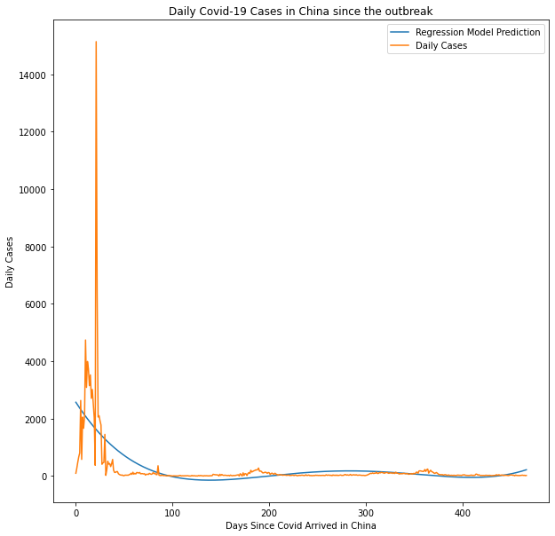

```python
from sklearn.preprocessing import PolynomialFeatures

# gathering the data for the China daily cases as well as the days since the outbreak started
chn_data = chn_data.iloc[1:]
china_cases = np.array(chn_data["new_cases"]).reshape(-1, 1)
china_days = np.arange(chn_data.shape[0]).reshape(-1, 1)

# training the poly regression model for the china data
china_poly = PolynomialFeatures(degree = 4)
china_x_poly = china_poly.fit_transform(china_days)
china_lin = LinearRegression()
china_lin.fit(china_x_poly, china_cases)


plt.figure(figsize = (10,10))
plt.plot(china_days, china_lin.predict(china_poly.fit_transform(china_days)), label = "Regression Model Prediction")
plt.plot(china_days, china_cases, label = "Daily Cases")
plt.title("Daily Covid-19 Cases in China since the outbreak")
plt.xlabel("Days Since Covid Arrived in China")
plt.ylabel("Daily Cases")
plt.legend()
plt.show()
```

For the Poly Regression model for China, it appears that it can predict the future cases with some accuracy but earlier, before day 100, the regression model is a poor representation of the Covid daily cases within China. Perhaps a larger degree for the poly regression model will solve this misrepresenatation.

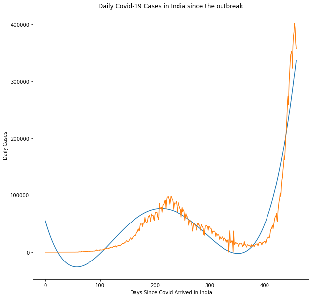

```python
# gathering the data for the India daily cases as well as the days since the outbreak started
ind_data = ind_data.iloc[1:]
india_cases = np.array(ind_data["new_cases"]).reshape(-1, 1)
india_days = np.arange(ind_data.shape[0]).reshape(-1, 1)


# training the poly regression model for the India data
india_poly = PolynomialFeatures(degree = 4)
india_x_poly = india_poly.fit_transform(india_days)
india_lin = LinearRegression()
india_lin.fit(india_x_poly, india_cases)


plt.figure(figsize = (10,10))
plt.plot(india_days, india_lin.predict(india_poly.fit_transform(india_days)))
plt.plot(india_days, india_cases)
plt.title("Daily Covid-19 Cases in India since the outbreak")
plt.xlabel("Days Since Covid Arrived in India")
plt.ylabel("Daily Cases")
plt.show()
```

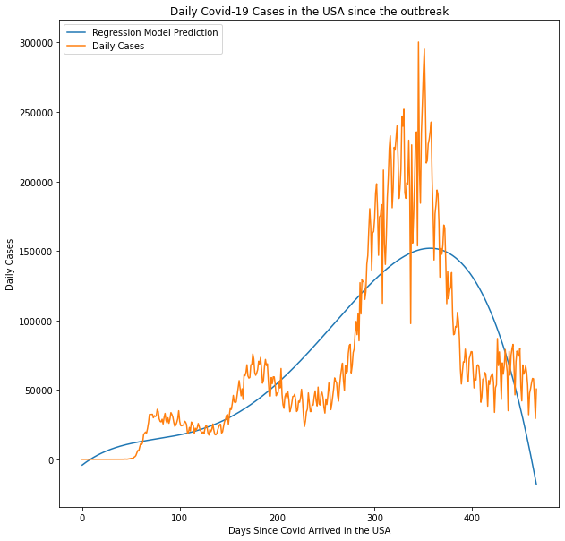

```python
# gathering the data for the USA daily cases as well as the days since the outbreak started
usa_data = usa_data.iloc[1:]
usa_cases = np.array(usa_data["new_cases"]).reshape(-1, 1)
usa_days = np.arange(usa_data.shape[0]).reshape(-1, 1)

# training the poly regression model for the USA data
usa_poly = PolynomialFeatures(degree = 4)
usa_x_poly = usa_poly.fit_transform(usa_days)
usa_lin = LinearRegression()
usa_lin.fit(usa_x_poly, usa_cases)


plt.figure(figsize = (10,10))
plt.plot(usa_days, usa_lin.predict(usa_poly.fit_transform(usa_days)), label = "Regression Model Prediction")
plt.plot(usa_days, usa_cases, label = "Daily Cases")
plt.title("Daily Covid-19 Cases in the USA since the outbreak")
plt.xlabel("Days Since Covid Arrived in the USA")
plt.ylabel("Daily Cases")
plt.legend()
plt.show()
```

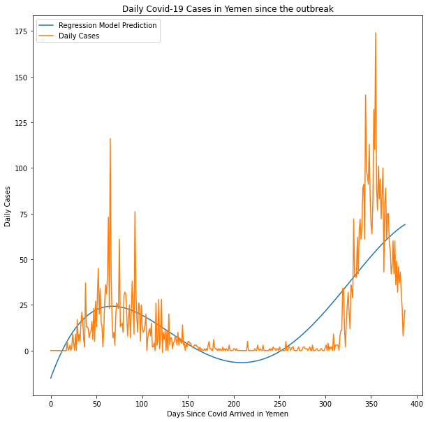

```python
# gathering the data for the Yemen daily cases as well as the days since the outbreak started
yem_data = yem_data.iloc[1:]
yem_cases = np.array(yem_data["new_cases"]).reshape(-1, 1)
yem_days = np.arange(yem_data.shape[0]).reshape(-1, 1)

# training the poly regression model for the Yemen data
yem_poly = PolynomialFeatures(degree = 4)
yem_x_poly = yem_poly.fit_transform(yem_days)
yem_lin = LinearRegression()
yem_lin.fit(yem_x_poly, yem_cases)


plt.figure(figsize = (10,10))
plt.plot(yem_days, yem_lin.predict(yem_poly.fit_transform(yem_days)), label = "Regression Model Prediction")
plt.plot(yem_days, yem_cases, label = "Daily Cases")
plt.title("Daily Covid-19 Cases in Yemen since the outbreak")
plt.xlabel("Days Since Covid Arrived in Yemen")
plt.ylabel("Daily Cases")
plt.legend()
plt.show()
```

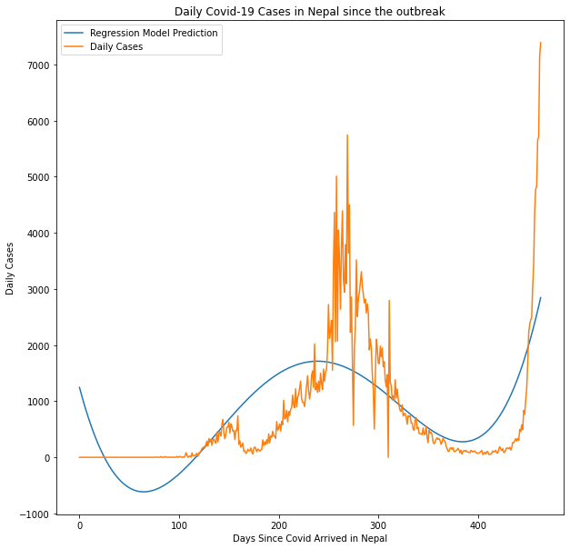

```python
# gathering the data for the Nepal daily cases as well as the days since the outbreak started
npl_data = npl_data.iloc[1:]
npl_cases = np.array(npl_data["new_cases"]).reshape(-1, 1)
npl_days = np.arange(npl_data.shape[0]).reshape(-1, 1)


# training the poly regression model for the Nepal data
npl_poly = PolynomialFeatures(degree = 4)
npl_x_poly = npl_poly.fit_transform(npl_days)
npl_lin = LinearRegression()
npl_lin.fit(npl_x_poly, npl_cases)


plt.figure(figsize = (10,10))
plt.plot(npl_days, npl_lin.predict(npl_poly.fit_transform(npl_days)), label = "Regression Model Prediction")
plt.plot(npl_days, npl_cases, label = "Daily Cases")
plt.title("Daily Covid-19 Cases in Nepal since the outbreak")
plt.xlabel("Days Since Covid Arrived in Nepal")
plt.ylabel("Daily Cases")
plt.legend()
plt.show()
```

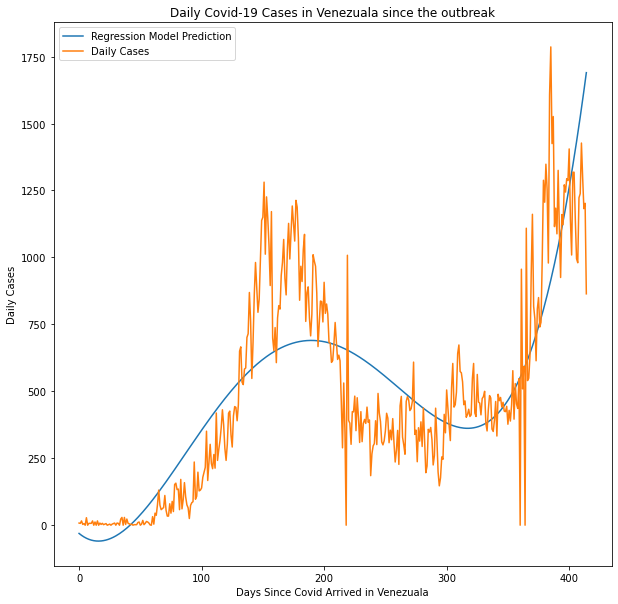

```python
# gathering the data for the Venezuala daily cases as well as the days since the outbreak started
ven_data = ven_data.iloc[1:]
ven_cases = np.array(ven_data["new_cases"]).reshape(-1, 1)
ven_days = np.arange(ven_data.shape[0]).reshape(-1, 1)

# training the poly regression model for the Venezuala data
ven_poly = PolynomialFeatures(degree = 4)
ven_x_poly = ven_poly.fit_transform(ven_days)
ven_lin = LinearRegression()
ven_lin.fit(ven_x_poly, ven_cases)


plt.figure(figsize = (10,10))
plt.plot(ven_days, ven_lin.predict(ven_poly.fit_transform(ven_days)), label = "Regression Model Prediction")
plt.plot(ven_days, ven_cases, label = "Daily Cases")
plt.title("Daily Covid-19 Cases in Venezuala since the outbreak")
plt.xlabel("Days Since Covid Arrived in Venezuala")
plt.ylabel("Daily Cases")
plt.legend()
plt.show()
```

From the multiple graphs showing the different poly regressions for each of the varying countries some of the poly regressions such as India and Venezuala where shown to be representitive of the daily cases and could be used to predict the future cases based on the data currently availible. However for countries such as China and Yemen, the poly regression was not representitive of the daily cases for the countries. Increasing, the poly regression degree may solve this issue. This goes to show that picking the correct degree for Poly regression is important for data analysis especially for data with this many fluctuations for all countries.

## Final Thoughts

In this tutorial, we analyzed the COVID-19 deaths and cases counts for the top 50 most populous countries.

In our data exploration section, we looked at total deaths/cases, proportion of deaths/cases, and average new deaths/cases. The graphs for totals and averages looked similar - a few countries looked like they were far more impacted by COVID than the rest of the countries. The proportion graphs took country population into account, and that resulted in the countries looking like they were more similarly impacted.

In hypothesis testing, we found that a larger proportion of deaths and cases often meant that the country was more severely impacted by COVID. This result is represented by rejecting the null hypothesis. There were 3 exceptions in cases - Kenya vs Ghana, Egypt vs Ethiopia, Ethiopia vs Mozambique and there was 1 exception in deaths - Vietnam vs Tanzania, where we failed to reject the null hypothesis.

We used machine learning to predict daily new case counts for the top 3 and bottom 3 populous countries in our data, specifically poly regression with n = 4. Our results showed that the regression was not always representative and couldn't always predict the future case counts for most countries. However, it could most accurately predict Venezuela and India. Additional work in this area such as increasing the poly regression degree may improve the prediction for other countries.

We hope this tutorial provided insight on the data science pipeline and on how countries are impacted by COVID-19. This tutorial is not meant to be comprehensive of all the analysis that could be performed on this dataset. Additional analysis can and should be performed for additional insights.